# Reading continuous time dynamics

```r
library(ctsem)
library(ggplot2)
```

The dynamic part of a ctsem model is a set of differential equations, and its parameters are rates of change per unit of time. This vignette explains how to read them: what the auto and cross effects mean, how to tell whether the processes are stable, how fast they change, what the effects are over a given time interval, and where the processes settle. The first sections use drift matrices with chosen values, and the last applies the same steps to a fitted model.

# One process

A single latent process $\eta$ follows

$$\mathrm{d}\eta(t) = \big(a\,\eta(t) + b\big)\,\mathrm{d}t + g\,\mathrm{d}W(t)$$

- $a$ is the auto effect, the `DRIFT` matrix. When $\eta$ is one unit above its equilibrium, it changes by $a$ units per unit of time. When $a$ is negative the process returns towards an equilibrium, faster the more negative it is. When $a$ is zero it has no equilibrium and wanders as a random walk. When $a$ is positive a deviation grows.
- $b$ is the continuous time intercept, `CINT`. With $a < 0$ the equilibrium is $-b/a$.
- $g$ is the size of the random shocks, `DIFFUSION`. With $a < 0$ the process varies around its equilibrium with variance $g^2 / (-2a)$.

Over a time interval $\Delta t$ the process is an autoregression with coefficient $e^{a \Delta t}$. A deviation from equilibrium halves in $\log(2) / |a|$ units of time, the half-life. The units are those of the time column in the data. With time in days, $a = -0.1$ gives a half-life of about 7 days. The same process with time in weeks has $a = -0.7$.

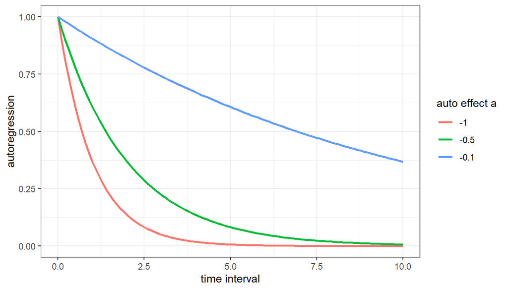

```r
intervals <- seq(0, 10, by = 0.1)
onep <- expand.grid(interval = intervals, a = c(-0.1, -0.5, -1))
onep$autoregression <- exp(onep$a * onep$interval)
ggplot(onep, aes(interval, autoregression, colour = factor(a))) +
  geom_line(linewidth = 1) + theme_bw() +
  labs(x = 'time interval', y = 'autoregression', colour = 'auto effect a')
```

```r
log(2) / c(0.1, 0.5, 1)   # half-lives
```

```
#> [1] 6.9314718 1.3862944 0.6931472
```

# Two processes

With more than one process, $a$ becomes the drift matrix $A$, $b$ the vector of intercepts, and $g$ a matrix $G$ whose product $GG^\top$ is the covariance of the shocks:

$$\mathrm{d}\boldsymbol\eta(t) = \big(A\,\boldsymbol\eta(t) + \mathbf b\big)\,\mathrm{d}t + G\,\mathrm{d}\mathbf W(t)$$

The diagonal of $A$ holds the auto effects. The entry in row $i$ and column $j$ is the cross effect of process $j$ on the rate of change of process $i$. In ctsem’s parameter names, `drift_eta2_eta1` is the effect of `eta1` on `eta2`.

A cross effect is a rate. What a discrete time model would estimate as a cross-lagged coefficient for an interval $\Delta t$ is an entry of the matrix exponential $e^{A \Delta t}$, which depends on the whole drift matrix and on the interval. In this system `eta1` drives `eta2`:

```r
A <- matrix(c(-0.4,  0,
               0.3, -0.2), 2, 2, byrow = TRUE,
  dimnames = list(c('eta1', 'eta2'), c('eta1', 'eta2')))
A
```

```
#>      eta1 eta2
#> eta1 -0.4  0.0
#> eta2  0.3 -0.2
```

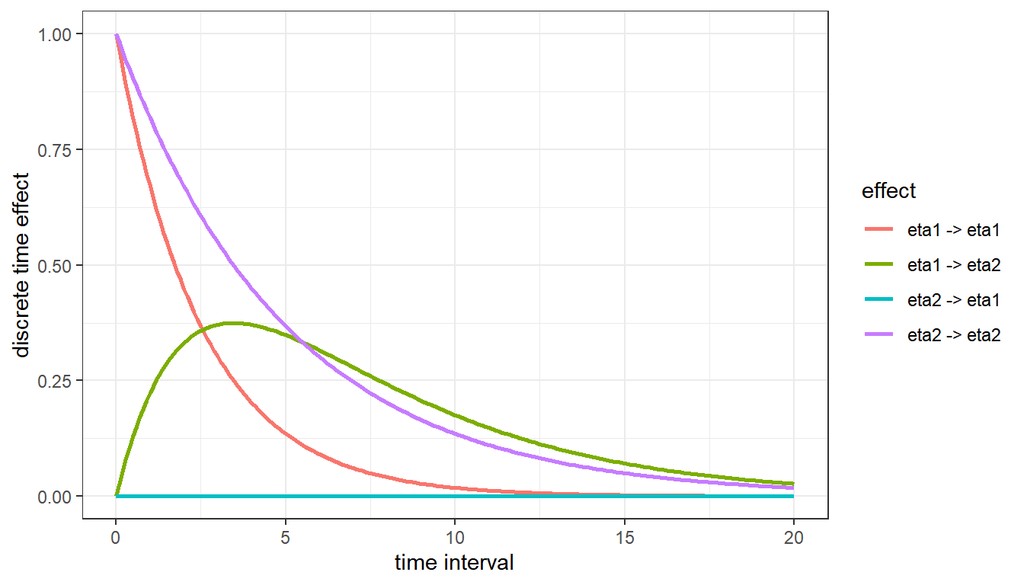

```r
discrete <- function(A, intervals) {
  do.call(rbind, lapply(intervals, function(dt) {
    E <- expm::expm(A * dt)
    data.frame(interval = dt, value = c(E),
      effect = paste(rep(colnames(A), each = nrow(A)), '->',
        rep(rownames(A), ncol(A))))
  }))
}
d2 <- discrete(A, seq(0, 20, by = 0.1))
ggplot(d2, aes(interval, value, colour = effect)) +
  geom_line(linewidth = 1) + theme_bw() +
  labs(x = 'time interval', y = 'discrete time effect')
```

The cross effect of `eta1` on `eta2` is zero over no time, rises as the change in `eta1` passes into `eta2`, and falls as both return to equilibrium. Its largest value is at an interval of about 3.5. A cross-lagged coefficient from a study with one interval between waves is one point on this curve, so two studies with different intervals can find quite different coefficients for the same process. A continuous time model fitted to either should give the same drift matrix.

# Stability

A system is stable when every disturbance fades and the processes return to their equilibrium. For one process that means $a < 0$. With more processes it depends on the whole drift matrix. The system is stable when every eigenvalue of $A$ has a negative real part. Negative auto effects do not ensure this, and a positive auto effect does not rule it out. For two processes the condition is the same as a negative sum of the auto effects together with a positive determinant of $A$.

Three drift matrices show this:

```r
drifts <- list(
  'negative auto effects, stable' =
    matrix(c(-0.5, 0.2, 0.2, -0.5), 2, 2, byrow = TRUE),
  'negative auto effects, unstable' =
    matrix(c(-0.5, 0.7, 0.7, -0.5), 2, 2, byrow = TRUE),
  'a positive auto effect, stable' =
    matrix(c(0.1, -0.6, 0.6, -0.5), 2, 2, byrow = TRUE))
lapply(drifts, function(A) eigen(A)$values)
```

```
#> $`negative auto effects, stable`
#> [1] -0.3 -0.7
#>
#> $`negative auto effects, unstable`
#> [1]  0.2 -1.2
#>
#> $`a positive auto effect, stable`
#> [1] -0.2+0.5196152i -0.2-0.5196152i
```

The second matrix has the same auto effects as the first, but the two processes push each other up strongly enough that a disturbance grows. Its eigenvalues are 0.2 and -1.2, and the positive one makes it unstable. The third has a positive auto effect for the first process, which on its own would grow, but the second process pulls it back. Its eigenvalues are complex with real part -0.2, so it is stable and oscillates. The trajectories after a disturbance of one unit in the first process, with no further shocks ($e^{At}$ times the disturbance):

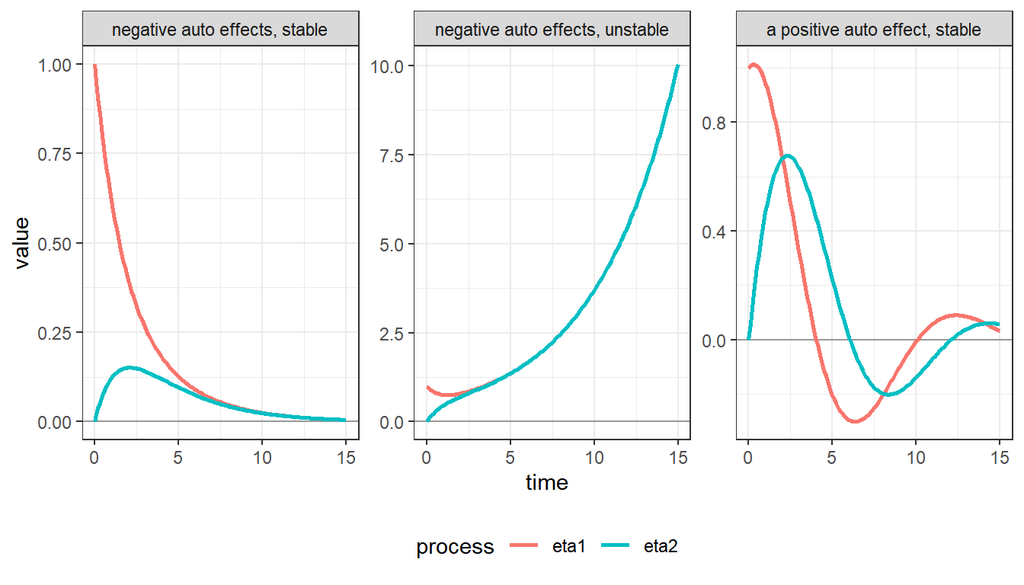

```r
trajectory <- function(A, start, times) {
  out <- t(sapply(times, function(t) expm::expm(A * t) %*% start))
  data.frame(time = times, eta1 = out[, 1], eta2 = out[, 2])
}
paths <- do.call(rbind, lapply(names(drifts), function(n) {
  p <- trajectory(drifts[[n]], start = c(1, 0), times = seq(0, 15, by = 0.1))
  rbind(data.frame(system = n, time = p$time, process = 'eta1', value = p$eta1),
        data.frame(system = n, time = p$time, process = 'eta2', value = p$eta2))
}))
paths$system <- factor(paths$system, levels = names(drifts))
ggplot(paths, aes(time, value, colour = process)) +
  geom_hline(yintercept = 0, colour = 'grey60') +
  geom_line(linewidth = 1) + facet_wrap(~system, scales = 'free_y') +
  theme_bw() + theme(legend.position = 'bottom')
```

An unstable system has no equilibrium to return to, so it has no stationary mean or variance. ctsem reports the asymptotic matrices described below as `NaN` for it. In a fitted model, an estimated drift matrix close to instability often means a slow process, such as a trend, that the model does not describe separately.

# How fast

The eigenvalues also give the time scale. Each real eigenvalue $\lambda$ belongs to a combination of the processes that returns to equilibrium at rate $\lambda$, with half-life $\log(2) / |\lambda|$. The eigenvalue with the real part nearest zero is the slowest, and sets how long the system as a whole takes to settle. In the first system above each auto effect alone would give a half-life of 1.4. The processes support each other, and the slowest combination has a half-life of 2.3:

```r
ev <- eigen(drifts[[1]])$values
log(2) / abs(Re(ev))
```

```
#> [1] 2.3104906 0.9902103
```

Complex eigenvalues mean oscillation. The period is $2\pi / |\mathrm{Im}\,\lambda|$, and the amplitude halves in $\log(2) / |\mathrm{Re}\,\lambda|$. For the third system:

```r
ev <- eigen(drifts[[3]])$values
c(period = 2 * pi / abs(Im(ev[1])), amplitude_halflife = log(2) / abs(Re(ev[1])))
```

```
#>             period amplitude_halflife
#>          12.091996           3.465736
```

A single process can only oscillate when it is modelled with a second, unseen process, its rate of change. `ctModelHigherOrder()` adds one to a model.

# Where the processes settle

A stable system fluctuates around its equilibrium with a stationary distribution, within each subject. Its mean is $-A^{-1}\mathbf b$, and its covariance $\Sigma$ solves $A\Sigma + \Sigma A^\top + GG^\top = 0$. ctsem reports these as `asymCINT` and `asymDIFFUSIONcov` (and the correlations as `asymDIFFUSIONcor`) in `summary(fit)$parmatrices` and `ctSummaryMatrices()`. For the first system with intercepts of 1 and 0 and independent unit shocks:

```r
A <- drifts[[1]]
b <- c(1, 0)
Q <- diag(2)                                    # G G'
-solve(A, b)                                    # equilibrium
```

```
#> [1] 2.380952 0.952381
```

```r
I <- diag(2)
matrix(-solve(kronecker(I, A) + kronecker(A, I), c(Q)), 2, 2)   # stationary covariance
```

```
#>           [,1]      [,2]
#> [1,] 1.1904762 0.4761905
#> [2,] 0.4761905 1.1904762
```

The second process has no intercept of its own, but it settles above zero because the first pushes it up.

# Comparing effects across processes

A cross effect is the change in process $i$ per unit of process $j$, so it depends on the units of both. When the processes are on different scales, the effects are easier to compare standardised by the stationary standard deviations, as the change in standard deviations of $i$ per standard deviation of $j$. `ctDiscretePars(fit, standardise = TRUE)` gives the discrete time effects on that scale, and `ctNetwork()` the network of effects at one interval.

# A fitted model

The README fits a model to the daily milk yield and fat percentage of 53 cows, with time in days. The same fit:

```r
data(milkman_rdm1, package = 'doBy')
milk <- data.frame(
  cow   = milkman_rdm1$cowno,
  day   = milkman_rdm1$dfc,
  yield = as.numeric(scale(milkman_rdm1$my)),
  fat   = as.numeric(scale(milkman_rdm1$fatpct)))

model <- ctModel(LAMBDA = diag(2), manifestNames = c('yield', 'fat'),
  latentNames = c('yield', 'fat'), time = 'day', id = 'cow')
fit <- ctFit(milk, model, cores = 2)
```

The estimated drift matrix, with each row the process that changes:

```r
est <- ctSummaryMatrices(fit)$estimate
est$DRIFT
```

```
#>              yield         fat
#> yield -0.040624783 -0.02013315
#> fat   -0.005850733 -0.01479395
```

```r
eigen(est$DRIFT)$values
```

```
#> [1] -0.04457951 -0.01083923
```

```r
log(2) / abs(eigen(est$DRIFT)$values)    # half-lives in days
```

```
#> [1] 15.54856 63.94801
```

Both eigenvalues are negative, so the two processes are stable together. The slower combination has a half-life of about two months, longer than either auto effect would give alone. The two cross effects form a loop that keeps a deviation going: higher fat lowers yield, and lower yield raises fat. Each draw of the fit’s parameters gives its own drift matrix, and so its own eigenvalues, which gives their uncertainty:

```r
draws <- ctExtract(fit)$pop_DRIFT
slowest <- apply(draws, 1, function(A) max(Re(eigen(A)$values)))
quantile(slowest, c(.025, .5, .975))
```

```
#>         2.5%          50%        97.5%
#> -0.019216464 -0.011094576 -0.005864885
```

```r
quantile(log(2) / abs(slowest), c(.025, .5, .975))   # its half-life in days
```

```
#>      2.5%       50%     97.5%
#>  36.07051  62.47623 118.18601
```

```r
mean(slowest < 0)                                     # share of draws that are stable
```

```
#> [1] 1
```

The discrete time effects, over intervals from a day to five months. The time range should cover the time scale of the processes, which ctsem cannot choose for you:

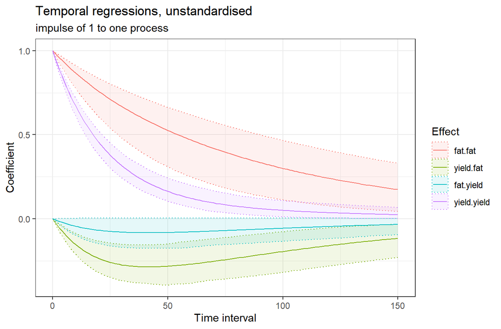

```r
ctDiscretePars(fit, times = seq(0, 150, by = 1), plot = TRUE)
```

`summary()` of the same output gives each curve’s peak, the interval at which it peaks, and the interval at which it has fallen to half the peak:

```r
dp <- ctDiscretePars(fit, times = seq(0, 150, by = 1))
s <- summary(dp)
s[s$quantity %in% c('peak', 'peaktime', 'halftime'),
  c('row', 'col', 'quantity', 'estimate', '2.5%', '97.5%')]
```

```
#>      row   col quantity     estimate       2.5%         97.5%
#> 1  yield yield     peak   1.00000000  1.0000000   1.000000000
#> 2  yield yield peaktime   0.00000000  0.0000000   0.000000000
#> 3  yield yield halftime  17.58797894 14.1670010  21.486224682
#> 5  yield   fat     peak  -0.28673526 -0.3976121  -0.156457119
#> 6  yield   fat peaktime  42.00000000 32.0000000  52.000000000
#> 7  yield   fat halftime 130.42280878 91.0829306 148.086281181
#> 9    fat yield     peak  -0.08332584 -0.1757231   0.005129223
#> 10   fat yield peaktime  42.00000000 32.0000000  52.000000000
#> 11   fat yield halftime 130.42280878 91.0829306 148.086281181
#> 13   fat   fat     peak   1.00000000  1.0000000   1.000000000
#> 14   fat   fat peaktime   0.00000000  0.0000000   0.000000000
#> 15   fat   fat halftime  54.38300646 28.3608718  89.896561192
```

A higher fat percentage is followed by a lower yield, most strongly after about six weeks, when one unit of fat (the data are standardised, so about one standard deviation) goes with a yield about 0.29 lower. The effect of yield on fat is smaller and its interval includes zero.

Within a cow, yield and fat vary together in the long run as well, through the cross effects and through shocks that affect both at once:

```r
est$DIFFUSIONcor          # correlation of the shocks
```

```
#>            yield        fat
#> yield  1.0000000 -0.5309896
#> fat   -0.5309896  1.0000000
```

```r
est$asymDIFFUSIONcor      # stationary correlation within a cow
```

```
#>            yield        fat
#> yield  1.0000000 -0.8113158
#> fat   -0.8113158  1.0000000
```

# State dependent dynamics

When a drift cell is an expression of the latent states, for example an auto effect that grows with the level of the process, the drift matrix differs from state to state, and so do its eigenvalues and the discrete time effects. Functions that report them then evaluate the model at one state and say which. `ctPhasePortrait()` and `ctStateDependencePlot()` show how the dynamics change across states.